# Lab 1 - R Primer

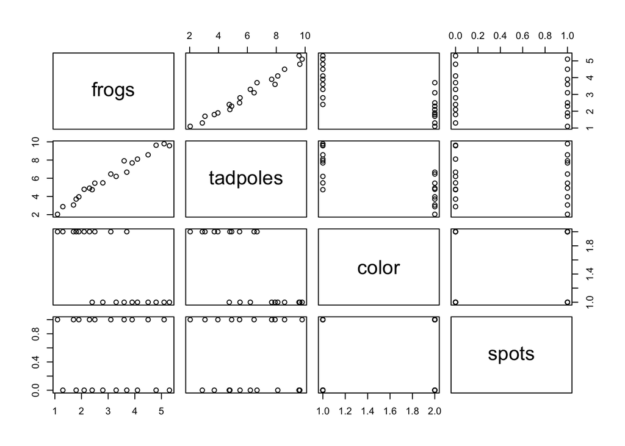

```r
pairs(dat)                  ## all pairwise scatter plots
```

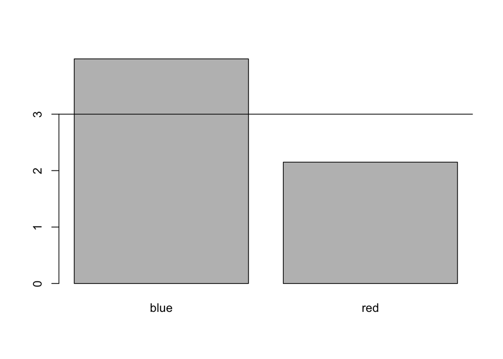

```r
barplot(tapply(dat$frogs,dat$color,mean))       ## barplot of frogs by color
abline(h=3)                 ## add a horizontal line at 3
```

The functions **lines** and **points** are also frequently used to add additional lines and points (respectively) to an existing plot.

Within the Plot window, graphs can be cut-and-pasted into other documents or saved to file fairly simply by using Export. If you want to automate the process of exporting graphics, for example when you generate a whole bunch of figures at once and don’t want to Export each one by hand, you’ll want to use the graphical functions such as ‘postscript’, ‘pdf’, or ‘tiff’. For all of these plot functions there are numerous additional (optional) arguments that control the formatting of the plots. The help for par (i.e. ?par) gives a fairly detailed list of these options, some of which you will see in further examples below.

19. Plot the following lines from 0 to 3 (hint: define x as a sequence with a small step size). Make sure to make the resolution of x sufficiently small to see the curves
1. ln(x)
2. $e^{-x}$
20. Make a barplot of the median number of frogs grouped by whether they have spots or not.
21. Plot a histogram of blue frogs
22. Use apply to calculate the across-population standard deviations in the numbers of frogs and tadpoles

## Classical tests

Since R evolved out of the statistical programming language S, it can easily perform a wide variety of statistical tests and analyses. In R linear regression is done with the function “lm” (linear models)

```r
reg1 = lm(tadpoles ~ frogs,data=dat)   #model syntax: y ~ x
reg1                 # default return from lm
```

```
##
## Call:
## lm(formula = tadpoles ~ frogs, data = dat)
##
## Coefficients:
## (Intercept)        frogs
##       0.455        1.836
```

```r
summary(reg1)                # detailed summary of results
```

```
##
## Call:
## lm(formula = tadpoles ~ frogs, data = dat)
##
## Residuals:
##     Min      1Q  Median      3Q     Max
## -0.6096 -0.1830 -0.0067  0.2538  0.8504
##
## Coefficients:
##             Estimate Std. Error t value Pr(>|t|)
## (Intercept)   0.4545     0.2321    1.96    0.066 .
## frogs         1.8358     0.0702   26.16    9e-16 ***
## ---
## Signif. codes:  0 '***' 0.001 '**' 0.01 '*' 0.05 '.' 0.1 ' ' 1
##
## Residual standard error: 0.39 on 18 degrees of freedom
## Multiple R-squared:  0.974,  Adjusted R-squared:  0.973
## F-statistic:  684 on 1 and 18 DF,  p-value: 8.97e-16
```

```r
anova(reg1)              # ANOVA table of results
```

```
## Analysis of Variance Table
##
## Response: tadpoles
##           Df Sum Sq Mean Sq F value Pr(>F)
## frogs      1  104.0   104.0     684  9e-16 ***
## Residuals 18    2.7     0.2
## ---
## Signif. codes:  0 '***' 0.001 '**' 0.01 '*' 0.05 '.' 0.1 ' ' 1
```

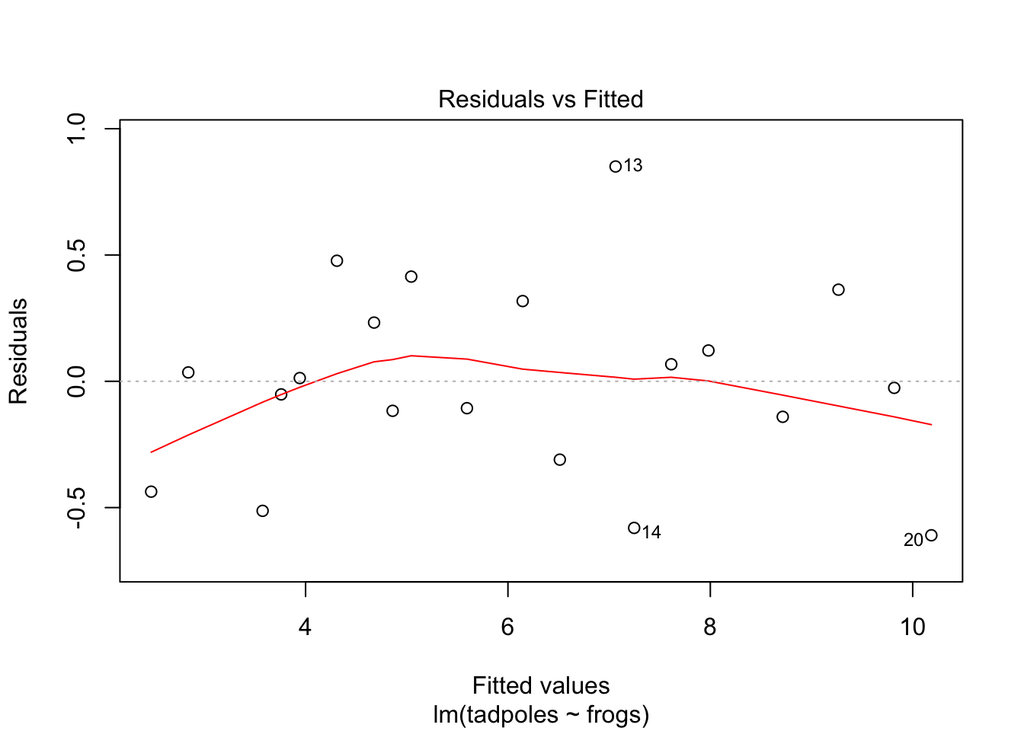

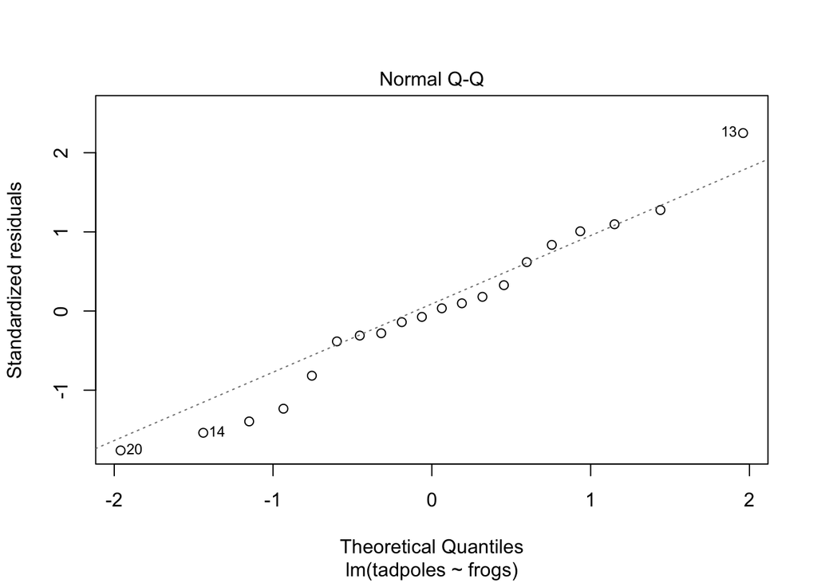

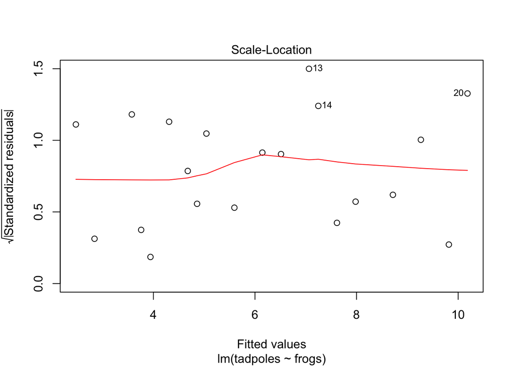

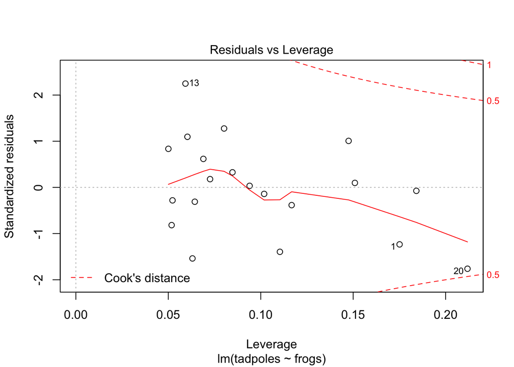

```r
plot(reg1)               # diagnostic plots (4 panels)
```

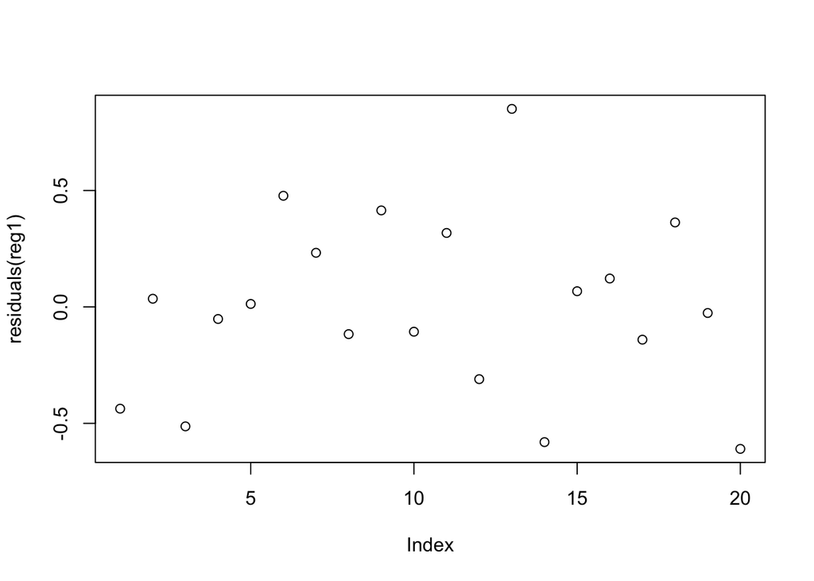

```r
plot(residuals(reg1))       # residuals by row
```

```r
coef(reg1)          # parameter coefficients
```

```
## (Intercept)       frogs
##      0.4545      1.8358
```

```r
vcov(reg1)          # parameter covariance matrix
```

```
##             (Intercept)     frogs
## (Intercept)     0.05388 -0.015098
## frogs          -0.01510  0.004926
```

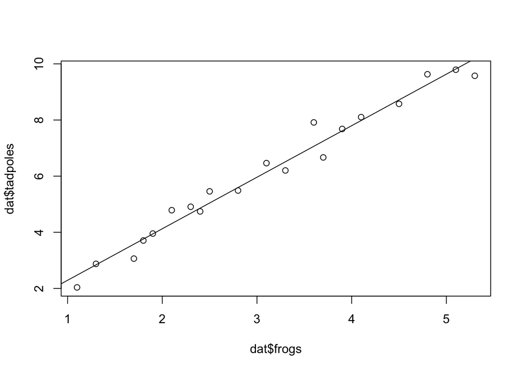

```r
plot(dat$frogs,dat$tadpoles)
abline(reg1)            # adding regression line to the scatter plot
```

The “equation” syntax for models in R often confuses people because while the order of the data is that you would use for writing down the equation [y = f(x)], it is the opposite order from the scatterplot (x,y). The equation syntax allows one to add additional variables to the regression model (e.g. y ~ x1 + x2). This syntax also makes it easy to specify interaction terms (y ~ x1 + x2 + x1*x2). Note that the linear model is returning an object and that all the other functions are acting on this object. You can use all the functions you used to explore data objects (e.g. class, names, str, summary) to explore the objects returned by functions. Similar to ‘lm’, ANOVA models are done with ‘aov’

```r
anov1 = aov(tadpoles ~ color + spots + color*spots,data=dat)
summary(anov1)
```

```
##             Df Sum Sq Mean Sq F value  Pr(>F)
## color        1   57.1    57.1   19.78 0.00041 ***
## spots        1    1.2     1.2    0.42 0.52597
## color:spots  1    2.3     2.3    0.81 0.38160
## Residuals   16   46.2     2.9
## ---
## Signif. codes:  0 '***' 0.001 '**' 0.01 '*' 0.05 '.' 0.1 ' ' 1
```

Finally, we can get a bit more sophisticated in our graphs to display these results. Note that R doesn’t care about white space—you can add spaces, tabs, and/or carriage returns wherever you want to make your code more readable.

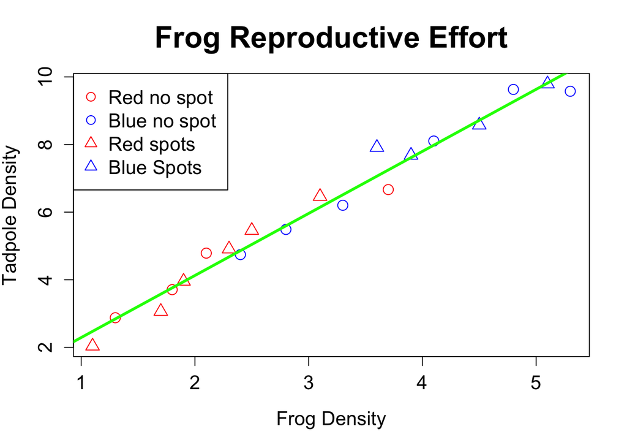

[output not shown]

```r
plot(dat$frogs,dat$tadpoles,
     cex=1.5,           # increase the symbol size
     col=as.character(dat$color),   # change the symbol color by name
     pch=dat$spots+1,           # change the symbol (by number)
     cex.axis=1.3,          # increase the font size on the axis
     xlab="Frog Density",       # label the x axis
     ylab="Tadpole Density",        # label the y axis
     cex.lab=1.3,           # increase the axis label font size
     main="Frog Reproductive Effort", # title
     cex.main=2         # increase title font size
     )
abline(reg1,col="green",        # add the regression line
     ,lwd=3)                # increase the line width
legend("topleft",
       c("Red no spot","Blue no spot","Red spots","Blue Spots"),
       pch=c(1,1,2,2),
       col=c("red","blue","red","blue"),cex=1.3
       )
```

## IF statements

Logical operators are not just used for subsetting data, but can be used to control the flow of an analysis and make decisions. The idea is that we want to tell the computer a set of rules, such as “if X happens, then do Y, otherwise do Z”. The syntax for this in R is

```
if(condition){
  ## Do Y
} else {
    ## Do Z
}
```

The “condition” part of this syntax is always a logical comparison, which does the first part (Y) if the condition is TRUE and the second part if it is FALSE. It should also be noted that the “else{ }” part of the syntax is optional, which would correspond to telling the computer, “if X do Y, otherwise just keep going”. For example, if we wanted to do integer division on integers but normal division otherwise we could write

```r
if(is.integer(x) & is.integer(y)){
  z = x %/% y   ## Do Integer division
} else {
    z = x/y             ## Do normal division
}
z
```

```
## [1] 0.10000 0.63636 0.08333 0.53846 0.07143 0.46667 0.33333 0.77778
```

It is also possible to string together multiple if statements sequentially to deal with multiple possible cases and outcomes. For example, we might want the above code to give us a warning if we try to do division on non-numeric data rather than failing with an error

```r
if(!is.numeric(x) | !is.numeric(y)){
  warning("Cannot perform division on non-numeric data")
}else if(is.integer(x) & is.integer(y)){
    z = x %/% y     ## Do Integer division
} else {
    z = x/y             ## Do normal division
}
z
```

```
## [1] 0.10000 0.63636 0.08333 0.53846 0.07143 0.46667 0.33333 0.77778
```

For cases where the outcomes are simple, or when we want to apply an ‘if’ to every element in a vector, then the ifelse function can be an efficient alternative. ifelse takes three arguments, the condition, what to do if its true, and what to do if its false. For example, the following checks the sign on the frog data before taking a log.

```r
ifelse(dat$frogs>0, log(dat$frogs),log(-dat$frogs))
```

```
##  [1] 0.09531 0.26236 0.53063 0.58779 0.64185 0.74194 0.83291 0.87547
##  [9] 0.91629 1.02962 1.13140 1.19392 1.28093 1.30833 1.36098 1.41099
## [17] 1.50408 1.56862 1.62924 1.66771
```

Aside: As is very common in R, as we learn more we often find more efficient ways of solving problems . For example, the above is equivalent to log(abs(dat$frogs))

```
24. Write an if statement that makes a scatter plot of x if all the values are positive, and plots a histogram otherwise.
```

## Defining custom functions

One of the powerful things about computer languages is that they allow us to encapsulate repetitive tasks into functions, making it easier to abstract a problem. In R you are not limited to the pre-defined functions but you can define your own functions as well. For example, if we found that we were repeating the previous block of ‘if’ code multiple places in our code, we might want to convert it to a function so that we could save on retyping the code again and again. Putting the code in one place also means that if we change the code we only need to change it once and it applies everywhere. At the extreme, its often argued that anything you do more than once in a piece of code should be converted to a function. So how do we define a function in R?

```
name = function(arguments){
  # do some calculations
    return(z)
}
```

We need to give it a name, for example we could call the previous if statement ‘my.division’, and we need to define the arguments to the function. We also need to be explicit in defining what data we want the function to return, since in many cases the outside user doesn’t need to know everything that goes on inside the function but is only interested in the result. Putting these together would give us the following

```r
my.division = function(x,y){
  if(!is.numeric(x) | !is.numeric(y)){
        warning("Cannot perform division on non-numeric data")
    }else if(is.integer(x) & is.integer(y)){
    z = x %/% y     ## Do Integer division
} else {
    z = x/y             ## Do normal division
}
    return(x)
}

my.division(x,y)
```

```
## [1] 1 7
```

```r
my.division(y,x)
```

```
## [1] 10 11 12 13 14 15  3  9
```

```r
my.division(x,"5")
```

```
## [1] 1 7
```

```
25. Convert the more complicated graphing example at the end of  “Classic Tests” into a function that will make the same plots for any data set. Show how you would call the function passing it just the subset of data where there are 5 or more tadpoles.
```

## For loops

Another powerful aspect of computers is there ability to easily repeat the same task time and time again. In fact, one of the major reasons many people learn to code is that they’ve figured out how to do some analysis once, but they want to apply the same analysis hundreds or thousands of times to different data sets, sites, individuals, pictures, etc. Doing so by clicking through a typical graphical user interface thousands of times if at best mind-numbing, if not outright impossible. Loops allow us to easily repeat an analysis over and over. The most common type of loop we will encounter is the for loop, which will repeat a chunk of code one time for each values specified by some sequence

```
for( variable in sequence){
  ## do something
}
```

As a very simple example, we might want to print the numbers 1:10

```r
for( i in 1:10){
  print(i)
}
```

```
## [1] 1
## [1] 2
## [1] 3
## [1] 4
## [1] 5
## [1] 6
## [1] 7
## [1] 8
## [1] 9
## [1] 10
```

A more complicated, but common, example might be to loop over all rows in a data set, or to loop over all files in a directory. We also commonly use for loops to do simple simulations. For example, if we want to simulate logistic growth, we might code it as follows:

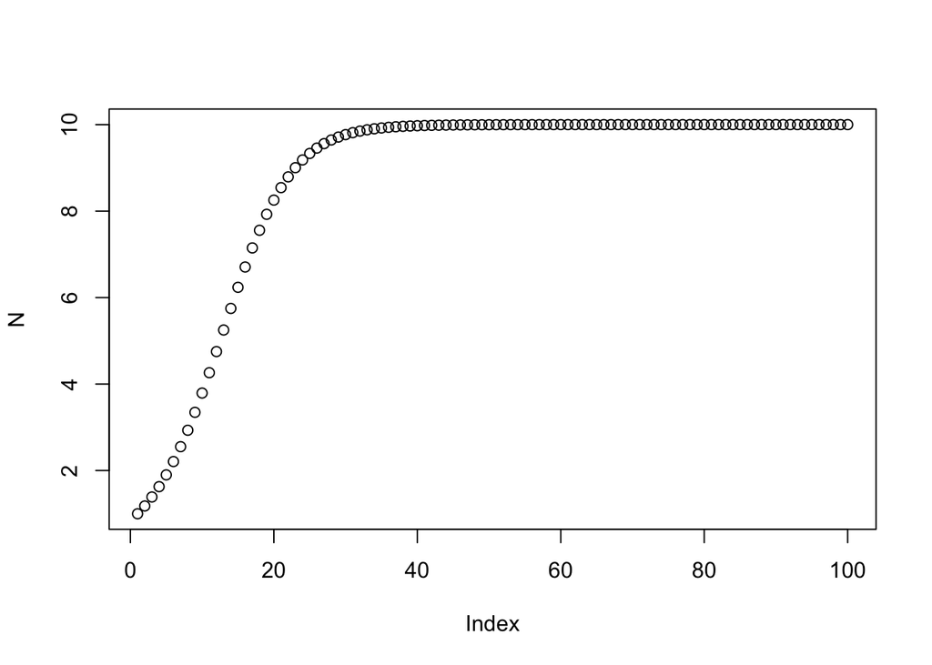

[output not shown]

```r
NT = 100        ## number of time steps
N0 = 1              ## initial population size
r = 0.2             ## population growth rate
K = 10              ## carrying capacity
N = rep(N0,NT)
for(t in 2:NT){
    N[t] = N[t-1] + r*N[t-1]*(1-N[t-1]/K)    ## discrete logistic growth
}
plot(N)
```

## Vector and Matrix Math

While loops are a powerful tool, there are many places where a calculation we want to perform can be done so directly on a vector or a matrix as a whole rather than having to loop through each value. For example, in question 26 we had a vector x = 1:10 and we wanted to add 5 to every value. We could have done this more simply as

```r
x + 5
```

```
## [1]  6 12
```

which adds 5 to each element. We can also multiply, divide, and subtract with vectors, and the operations are applied to each element

```r
5*x
```

```
## [1]  5 35
```

```r
x/5
```

```
## [1] 0.2 1.4
```

```r
x-5
```

```
## [1] -4  2
```

Furthermore, if we have two or more vectors, and we perform mathematical operations on them, the operations are performed element by element

```r
y = 10:1
x*y
```

```
##  [1] 10 63  8 49  6 35  4 21  2  7
```

```r
x-y
```

```
##  [1] -9 -2 -7  0 -5  2 -3  4 -1  6
```

```r
x/y
```

```
##  [1] 0.1000 0.7778 0.1250 1.0000 0.1667 1.4000 0.2500 2.3333 0.5000 7.0000
```

```r
dat$frogs + dat$tadpoles
```

```
##  [1]  3.137  4.176  4.763  5.507  5.855  6.887  7.209  7.144  7.959  8.288
## [11]  9.563  9.503 11.514 10.367 11.582 12.203 13.075 14.429 14.891 14.875
```

R also allows us to define matrices and perform element-wise math on them as well

```r
z = matrix(1:25,5,5)
z
```

```
##      [,1] [,2] [,3] [,4] [,5]
## [1,]    1    6   11   16   21
## [2,]    2    7   12   17   22
## [3,]    3    8   13   18   23
## [4,]    4    9   14   19   24
## [5,]    5   10   15   20   25
```

```r
z + 5
```

```
##      [,1] [,2] [,3] [,4] [,5]
## [1,]    6   11   16   21   26
## [2,]    7   12   17   22   27
## [3,]    8   13   18   23   28
## [4,]    9   14   19   24   29
## [5,]   10   15   20   25   30
```

```r
z*5
```

```
##      [,1] [,2] [,3] [,4] [,5]
## [1,]    5   30   55   80  105
## [2,]   10   35   60   85  110
## [3,]   15   40   65   90  115
## [4,]   20   45   70   95  120
## [5,]   25   50   75  100  125
```

```r
z - 1:5
```

```
##      [,1] [,2] [,3] [,4] [,5]
## [1,]    0    5   10   15   20
## [2,]    0    5   10   15   20
## [3,]    0    5   10   15   20
## [4,]    0    5   10   15   20
## [5,]    0    5   10   15   20
```

The last example shows that we can also perform element-wise math between a matrix and a vector. Similarly, matrix-to-matrix math is also allowed, though for these cases you need to pay a lot of attention to the dimensions of the matrices and the order that vectors are being applied. In addition to element-wise math, R can also perform standard matrix math. If you have not seen this math before you don’t need to worry about what it is doing at this point, any matrix operations will be explained on a case-by-case later in the semester.

```r
t(z)        ## transpose
```

```
##      [,1] [,2] [,3] [,4] [,5]
## [1,]    1    2    3    4    5
## [2,]    6    7    8    9   10
## [3,]   11   12   13   14   15
## [4,]   16   17   18   19   20
## [5,]   21   22   23   24   25
```

```r
diag(z)         ## diagonal of an existing matrix
```

```
## [1]  1  7 13 19 25
```

```r
diag(1,5)   ## create a diagonal matrix
```

```
##      [,1] [,2] [,3] [,4] [,5]
## [1,]    1    0    0    0    0
## [2,]    0    1    0    0    0
## [3,]    0    0    1    0    0
## [4,]    0    0    0    1    0
## [5,]    0    0    0    0    1
```

```r
w = z + diag(1,5) ## matrix addition
w
```

```
##      [,1] [,2] [,3] [,4] [,5]
## [1,]    2    6   11   16   21
## [2,]    2    8   12   17   22
## [3,]    3    8   14   18   23
## [4,]    4    9   14   20   24
## [5,]    5   10   15   20   26
```

```r
solve(w)        ## inversion
```

```
##          [,1]     [,2]    [,3]     [,4]    [,5]
## [1,]  0.19022 -0.51087 -0.2120  0.08696  0.3859
## [2,] -0.53261  0.63043 -0.2065 -0.04348  0.1196
## [3,] -0.25543 -0.22826  0.7989 -0.17391 -0.1467
## [4,]  0.02174 -0.08696 -0.1957  0.69565 -0.4130
## [5,]  0.29891  0.05435 -0.1902 -0.43478  0.3207
```

```r
crossprod(z,z)      ## cross product
```

```
##      [,1] [,2] [,3] [,4] [,5]
## [1,]   55  130  205  280  355
## [2,]  130  330  530  730  930
## [3,]  205  530  855 1180 1505
## [4,]  280  730 1180 1630 2080
## [5,]  355  930 1505 2080 2655
```

```r
z %*% z         ## matrix multiplication
```

```
##      [,1] [,2] [,3] [,4] [,5]
## [1,]  215  490  765 1040 1315
## [2,]  230  530  830 1130 1430
## [3,]  245  570  895 1220 1545
## [4,]  260  610  960 1310 1660
## [5,]  275  650 1025 1400 1775
```

## Not covered…

While this summary is really just the tip of the iceberg relative to the full depth of available functions and packages in R, there are a few major topics that will be introduced in later exercises but which you would be encouraged to look ahead to. These include how R treats probability distributions and random numbers, missing values (NA), and a very flexible data structure called a list. As the course progresses you will also be exposed to more examples of R code, the structure of R packages, command line execution, how to read a write a larger suite of data types, and how R interfaces with a few other software systems.

## Synopsis

Most of this document is meant to familiarize you with R, so that when you encounter a problem you need to solve you will have a vague memory of something that might work and can use this as a reference. Over time you will come to memorize a larger fraction of this and through exploration you will find many additional functions and coding techniques that are useful. However, here are some parting thoughts on what you should take home at the end of the day.

If you have never programmed before:

- Focus first on the core concepts that define almost all programming languages
- Mathematical operators
- Logical operators
- Indexing of vectors, matrices, and data frames
- If statements
- For loops
- Functions
- Programming, at its essence, is a process of breaking down a complicated problem into a series of very simple steps, and then translating those steps into a symbolic language (code). This document is mostly about the vocabulary and syntax of one such language (R), the fun and creative process of using this language for problem solving will come through examples and experience.

If you know another language and are picking up R:

- The hardest transition will be SYNTAX

Everyone:

- Save code early and often
- Even better is to commit your code in a version control system like git
- Commit code frequently, typically one new feature per commit
- Keep code well documented
- Use meaningful variable names
- Develop a habit of actively searching and exploring R.
- Read the help documents for a function
- Search for new functions and techniques
- Scour the web when debugging.
- The key to good programming is being able to teach yourself